# Introduction to Single Cell Analysis

COVID-19 Edition

Dr. Elana Fertig, Spring 2020

### Week 3

Step-by-step analysis: Gubin, Matthew M et al. “High-Dimensional Analysis Delineates Myeloid and Lymphoid Compartment Remodeling during Successful Immune-Checkpoint Cancer Therapy.” Cell 175.4 (2018): 1014-1030.e19.

### Loading Packages and Seurat Object

#### Load Packages

```r
library(plyr)
library(Matrix)
library(Seurat)
library(ggplot2)
library(cowplot)
library(metap)
library(multtest)
library(ComplexHeatmap)
#BiocManager::install("DESeq2")
library(DESeq2)
#install.packages("msigbr")
library(msigdbr)
#BiocManager::install("fgsea")
library(fgsea)
```

#### Load Seurat Object

```r
sobj<-readRDS(file="SingleCellCourseSeuratObject_Wk2S2.rds")
```

### Identify Differentially Expressed Genes Across Treatments

Now we can start to do comparative analyses and look at the differences induced by treatment. One way to look broadly at these changes is to plot the average expression of both the treated and control cells and look for genes that are visual outliers on a scatter plot.

#### Natural Killer Cells

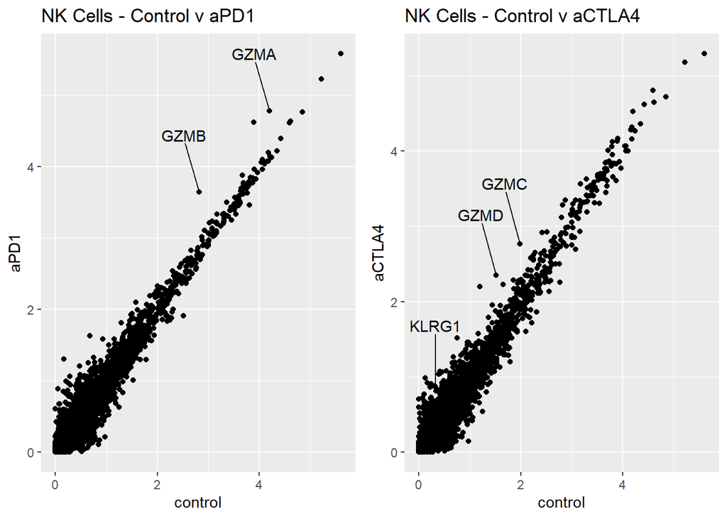

```r
nk.cells <- subset(sobj, idents = "NK Cells")
Idents(nk.cells) <- "treatment"
avg.nk.cells <- log1p(AverageExpression(nk.cells, verbose = FALSE)$RNA)
avg.nk.cells$gene <- rownames(avg.nk.cells)


p1<-ggplot(avg.nk.cells, aes(control, aPD1)) + geom_point() +  ggtitle("NK Cells - Control v aPD1")
p1 <- LabelPoints(plot = p1, points = c("GZMB","GZMA"), ynudge = .8,xnudge=-.3, repel = TRUE)

p2<-ggplot(avg.nk.cells, aes(control, aCTLA4)) + geom_point() +  ggtitle("NK Cells - Control v aCTLA4")
p2 <- LabelPoints(plot = p2, points = c("GZMC","GZMD","KLRG1"), ynudge = .8,xnudge=-.3, repel = TRUE)
plot_grid(p1, p2)
```

##### Control v aPD1

###### Find Marker Genes

We can also look at differences induced by treatment using statistical tests. In Seurat, the `FindMarkers` function can be used to identify which genes are different between control and treatment. The defaul test is a Wilcoxon rank sum test.

```r
sobjNK<-sobj
sobjNK$celltype.treatment <- paste(Idents(sobjNK), sobjNK$treatment, sep = "_")
sobjNK$celltype <- Idents(sobjNK)
Idents(sobjNK) <- "celltype.treatment"
NK.response <- FindMarkers(sobjNK, ident.1 = "NK Cells_control", ident.2 = "NK Cells_aPD1", verbose = FALSE)
head(NK.response, n = 10)
```

|  | p_val | avg_logFC | pct.1 | pct.2 | p_val_adj |
| --- | --- | --- | --- | --- | --- |
| CCL8 | 0.00e+00 | -0.6097721 | 0.109 | 0.410 | 0.0000000 |
| GZMA | 0.00e+00 | -0.5756183 | 0.778 | 0.913 | 0.0000007 |
| CD52 | 0.00e+00 | 0.3435551 | 0.969 | 0.932 | 0.0000144 |
| GZMB | 0.00e+00 | -0.8213575 | 0.606 | 0.705 | 0.0004286 |
| CD7 | 7.00e-07 | 0.3646806 | 0.578 | 0.366 | 0.0192082 |
| PIM1 | 6.70e-06 | -0.4321697 | 0.259 | 0.432 | 0.1870136 |
| BCL2 | 2.46e-05 | 0.3364729 | 0.666 | 0.522 | 0.6892787 |
| KLRC1 | 3.07e-05 | 0.3238070 | 0.497 | 0.320 | 0.8599506 |
| CCL5 | 3.68e-05 | -0.7217656 | 0.497 | 0.640 | 1.0000000 |
| CD160 | 1.01e-04 | 0.3876878 | 0.238 | 0.121 | 1.0000000 |

We can choose a specific tests we would like with `test.use` in the `FindMarkers` function. To prefrom differential expressoin anlysis using the negative bionomial distribution, we will specify `test.use="DESeq2"`. Other tests can be found [here.](https://satijalab.org/seurat/v3.1/de_vignette.html)

```r
NK.response <- FindMarkers(sobjNK, ident.1 = "NK Cells_control", ident.2 = "NK Cells_aPD1",test.use="DESeq2", verbose = FALSE)
head(NK.response, n = 10)
```

|  | p_val | avg_logFC | pct.1 | pct.2 | p_val_adj |
| --- | --- | --- | --- | --- | --- |
| GZMB | 0.00e+00 | -0.9215468 | 0.606 | 0.705 | 0.0000000 |
| CD52 | 0.00e+00 | 0.2264671 | 0.969 | 0.932 | 0.0001406 |
| GZMA | 0.00e+00 | -0.7332341 | 0.778 | 0.913 | 0.0008309 |
| PKM | 1.70e-06 | -0.3129065 | 0.566 | 0.646 | 0.0462492 |
| NKG7 | 4.30e-06 | -0.2357359 | 0.991 | 0.988 | 0.1213074 |
| CCL5 | 6.50e-06 | -0.5623287 | 0.497 | 0.640 | 0.1816599 |
| CDC42 | 6.70e-06 | -0.2662893 | 0.662 | 0.745 | 0.1876984 |
| MIF | 8.40e-06 | -0.3468343 | 0.438 | 0.478 | 0.2356701 |
| OSTF1 | 1.10e-05 | 0.1778665 | 0.722 | 0.621 | 0.3079475 |
| RAN | 2.48e-05 | -0.3098405 | 0.488 | 0.531 | 0.6944935 |

##### Control v aCTLA4

###### Find Marker Genes

```r
NK.response <- FindMarkers(sobjNK, ident.1 = "NK Cells_control", ident.2 = "NK Cells_aCTLA4", verbose = FALSE)
head(NK.response, n = 35)
```

|  | p_val | avg_logFC | pct.1 | pct.2 | p_val_adj |
| --- | --- | --- | --- | --- | --- |
| GM10076 | 0.0e+00 | -0.4770050 | 0.903 | 0.957 | 0.0000000 |
| UBA52 | 0.0e+00 | -0.3974401 | 0.950 | 0.975 | 0.0000000 |
| RPL35 | 0.0e+00 | -0.3318088 | 0.988 | 0.993 | 0.0000000 |
| MALAT1 | 0.0e+00 | 0.3127978 | 1.000 | 0.996 | 0.0000000 |
| GM8730 | 0.0e+00 | -0.2972772 | 0.975 | 0.996 | 0.0000000 |
| RPLP0 | 0.0e+00 | -0.2713671 | 0.981 | 0.996 | 0.0000001 |
| RPS27RT | 0.0e+00 | 0.2695148 | 0.997 | 0.982 | 0.0000001 |
| GZMC | 0.0e+00 | -0.7901763 | 0.216 | 0.477 | 0.0000002 |
| ALDOA | 0.0e+00 | -0.3853872 | 0.650 | 0.822 | 0.0000015 |
| NCR1 | 0.0e+00 | 0.5159938 | 0.803 | 0.673 | 0.0000019 |
| GZMD | 0.0e+00 | -0.8391073 | 0.075 | 0.274 | 0.0000023 |
| PGK1 | 0.0e+00 | -0.5278517 | 0.156 | 0.395 | 0.0000029 |
| RPS19 | 0.0e+00 | -0.2626331 | 0.997 | 0.982 | 0.0000040 |
| BCL2 | 0.0e+00 | 0.5002858 | 0.666 | 0.502 | 0.0000336 |
| GAPDH | 0.0e+00 | -0.3077793 | 0.556 | 0.715 | 0.0000793 |
| MS4A4B | 0.0e+00 | 0.3811574 | 0.912 | 0.819 | 0.0001003 |
| GADD45G | 0.0e+00 | -0.7704754 | 0.131 | 0.338 | 0.0001316 |
| RPL29 | 0.0e+00 | -0.4221156 | 0.428 | 0.662 | 0.0001850 |
| GPI1 | 0.0e+00 | -0.4049490 | 0.319 | 0.594 | 0.0002112 |
| KLRG1 | 0.0e+00 | -0.5595639 | 0.066 | 0.231 | 0.0003005 |
| ENO1B | 0.0e+00 | -0.3028518 | 0.044 | 0.192 | 0.0006852 |
| FTL1 | 1.0e-07 | -0.3334219 | 0.925 | 0.979 | 0.0015575 |
| GM10116 | 1.0e-07 | -0.4608581 | 0.169 | 0.367 | 0.0028803 |
| TIMM8B | 2.0e-07 | -0.3267909 | 0.122 | 0.313 | 0.0056140 |
| GM10020 | 2.0e-07 | -0.3815388 | 0.253 | 0.477 | 0.0057293 |
| GZME | 2.0e-07 | -0.4464540 | 0.069 | 0.217 | 0.0060855 |
| SPP1 | 3.0e-07 | -0.4982759 | 0.294 | 0.495 | 0.0087739 |
| CD7 | 6.0e-07 | 0.3041008 | 0.578 | 0.384 | 0.0166982 |
| MBNL1 | 1.0e-06 | 0.4758893 | 0.562 | 0.445 | 0.0293912 |
| IMPA2 | 1.3e-06 | -0.3229157 | 0.109 | 0.267 | 0.0366608 |
| GZMB | 1.4e-06 | -0.4634855 | 0.606 | 0.758 | 0.0391085 |
| RPS2 | 1.5e-06 | -0.2702883 | 0.919 | 0.950 | 0.0423564 |
| RPSA | 1.8e-06 | -0.3172885 | 0.878 | 0.929 | 0.0513686 |
| EEF1G | 3.1e-06 | -0.3145294 | 0.691 | 0.840 | 0.0860395 |
| PRF1 | 3.6e-06 | -0.3476805 | 0.144 | 0.310 | 0.1008702 |

###### Preform Differetial Expression Analysis using DESeq2

```r
NK.response <- FindMarkers(sobjNK, ident.1 = "NK Cells_control", ident.2 = "NK Cells_aCTLA4", test.use = "DESeq2", verbose = FALSE)
head(NK.response, n = 30)
```

|  | p_val | avg_logFC | pct.1 | pct.2 | p_val_adj |
| --- | --- | --- | --- | --- | --- |
| RPS27RT | 0.0e+00 | -0.0297864 | 0.997 | 0.982 | 0.0000000 |
| GM10076 | 0.0e+00 | -0.8121772 | 0.903 | 0.957 | 0.0000000 |
| UBA52 | 0.0e+00 | -0.6966996 | 0.950 | 0.975 | 0.0000000 |
| RPL35 | 0.0e+00 | -0.7192968 | 0.988 | 0.993 | 0.0000000 |
| GM8730 | 0.0e+00 | -0.6754740 | 0.975 | 0.996 | 0.0000000 |
| RPLP0 | 0.0e+00 | -0.6595418 | 0.981 | 0.996 | 0.0000002 |
| NCR1 | 0.0e+00 | 0.1590618 | 0.803 | 0.673 | 0.0000003 |
| RPL41 | 0.0e+00 | -0.6550567 | 1.000 | 1.000 | 0.0000015 |
| MBNL1 | 0.0e+00 | 0.1300438 | 0.562 | 0.445 | 0.0000019 |
| BCL2 | 0.0e+00 | 0.1894644 | 0.666 | 0.502 | 0.0000032 |
| MALAT1 | 0.0e+00 | 0.0564914 | 1.000 | 0.996 | 0.0000040 |
| RPS19 | 0.0e+00 | -0.6681621 | 0.997 | 0.982 | 0.0000123 |
| CTSW | 0.0e+00 | 0.0772058 | 0.691 | 0.644 | 0.0000126 |
| MS4A4B | 0.0e+00 | 0.0574363 | 0.912 | 0.819 | 0.0000477 |
| RPS27 | 0.0e+00 | -0.1741052 | 1.000 | 1.000 | 0.0000537 |
| RPL29 | 0.0e+00 | -0.5216923 | 0.428 | 0.662 | 0.0001485 |
| RPSA | 0.0e+00 | -0.6413516 | 0.878 | 0.929 | 0.0012602 |
| H3F3A | 0.0e+00 | 0.0023851 | 0.706 | 0.694 | 0.0012851 |
| GM8797 | 1.0e-07 | -0.1159086 | 0.959 | 0.915 | 0.0018342 |
| MT.ND1 | 1.0e-07 | 0.0060922 | 0.825 | 0.747 | 0.0028233 |
| H2.Q7 | 1.0e-07 | 0.1248791 | 0.581 | 0.466 | 0.0032685 |
| RPS2 | 2.0e-07 | -0.6488297 | 0.919 | 0.950 | 0.0054009 |
| ALDOA | 2.0e-07 | -0.6447376 | 0.650 | 0.822 | 0.0066394 |
| GPR171 | 3.0e-07 | 0.1231982 | 0.412 | 0.381 | 0.0092236 |
| KLRB1C | 4.0e-07 | 0.0829557 | 0.494 | 0.431 | 0.0118976 |
| KLRB1F | 5.0e-07 | 0.1415864 | 0.384 | 0.256 | 0.0140139 |
| RPL13 | 9.0e-07 | -0.5644174 | 1.000 | 1.000 | 0.0260994 |
| H2.K1 | 1.8e-06 | -0.0467402 | 0.956 | 0.907 | 0.0504409 |
| ENO1 | 2.1e-06 | -0.6645859 | 0.575 | 0.705 | 0.0598604 |
| GM2000 | 2.4e-06 | -0.4731358 | 0.484 | 0.680 | 0.0661066 |

### Visualize results using ComplexHeatmap

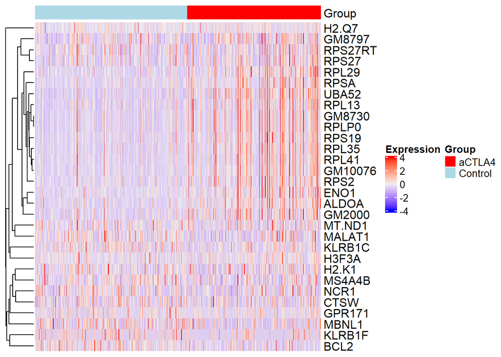

```r
# get barcodes and subset counts matrix for the cells being compared and the top 30 genes
control <- WhichCells(object = sobjNK, idents = "NK Cells_control")
treatment <- WhichCells(object = sobjNK, idents = "NK Cells_aCTLA4")
topGenes <- rownames(head(NK.response, n = 30))
mat <- data.frame(sobjNK[["RNA"]]@counts[topGenes,c(control,treatment)])
mat <- t(apply(mat,1,scale))

# create cell annotations
pdat <- rbind(data.frame(Barcodes = control,Group="Control"), data.frame(Barcodes = treatment,Group="aCTLA4"))
columnHA <- HeatmapAnnotation(Group = pdat$Group,
                              col = list(Group = c("aCTLA4" = "red", "Control" = "lightblue")))

Heatmap(mat, cluster_columns = F,
        clustering_distance_rows = 'pearson',
        name="Expression",
        top_annotation = columnHA)
```

### Calculate Average Log Fold Change Between Control NK cells and aCTL4-treated NK Cells

```r
av=suppressMessages(AverageExpression(sobjNK,assays='RNA'))
av=data.frame(apply(av[['RNA']],FUN=function(x) log(x+1),MARGIN=c(1,2)))

# Directionality depends on order of calculation, a positive logFC here means upregulated expression in treatment
nk_foldChanges=data.frame(genes=rownames(av),avg_logFC= av$NK.Cells_aCTLA4-av$NK.Cells_control)
```

### Perform Gene Set Enrichment Analysis using msigbr pathways and fgsea

###### msigbr has a large collection of gene sets: category “H” = hallmark; “C6” = oncogenic signatures; “C7” = immunologic signatures; “C2” = curated gene sets divided into CGP and CP (kegg, reactome); “C5” = GO pathways divided into MF, BP, CC

```r
# Load pathways
msigdbr_show_species()
```

```
##  [1] "Bos taurus"               "Caenorhabditis elegans"
##  [3] "Canis lupus familiaris"   "Danio rerio"
##  [5] "Drosophila melanogaster"  "Gallus gallus"
##  [7] "Homo sapiens"             "Mus musculus"
##  [9] "Rattus norvegicus"        "Saccharomyces cerevisiae"
## [11] "Sus scrofa"
```

```r
m_df = msigdbr(species = "Mus musculus", category = "C2",subcategory = "CGP")
# convert tibble to a dataframe
m_t2g = m_df %>% dplyr::select(gs_name, gene_symbol) %>% as.data.frame()
# convert dataframe to a list of pathways
m_list <- split(m_t2g$gene_symbol, m_t2g$gs_name)

# Rename genes to upper case, this has to be consistent with your seurat object gene naming scheme
for (geneset in names(m_list)){
  m_list[[geneset]] <- toupper(m_list[[geneset]])
}

# Prep genes for fgsea
gene_list = nk_foldChanges$avg_logFC
names(gene_list) = as.character(nk_foldChanges$genes)
gene_list = sort(gene_list, decreasing = TRUE)

# Run fgsea
fgRes <- fgsea(pathways = m_list,
                      stats = gene_list,
                       minSize=15,
                      maxSize=700)
# Keep only the pathways with an adjusted p value below 0.05
fgRes %>%
  as.data.frame() %>%
  dplyr::filter(padj < !!0.05)
```

| pathway | pval | padj | log2err | ES | NES | size | leadingEdge |
| --- | --- | --- | --- | --- | --- | --- | --- |
| BILANGES_SERUM_AND_RAPAMYCIN_SENSITIVE_GENES | 3.08e-05 | 0.0245749 | 0.5573322 | 0.8216692 | 1.817184 | 66 | c(“RPL29”, “UBA52”, “EEF1G”, “RPS19”, “RPL7A”, “RPL28”, “RPL15”, “RPL36A”, “RPL26”, “RPL13”, “RPS4X”, “RPS5”, “RPL7”, “RPL23”, “PTMS”, “RPL6”, “EIF3M”, “RPS3A1”, “EIF3F”, “RPS6”, “RPL32”, “RPS8”, “RPS… |
| BILANGES_SERUM_RESPONSE_TRANSLATION | 7.78e-05 | 0.0406703 | 0.5384341 | 0.9025801 | 1.761757 | 33 | c(“RPL29”, “EEF1G”, “RPS19”, “RPS4X”, “RPS5”, “PTMS”, “RPL6”, “EIF3F”, “RPS6”, “RPS8”, “RPS3”, “RPL10”, “RPS7”, “EEF1B2”, “NSA2”, “RPL14”, “EEF1A1”, “RPL21”, “EIF3H”, “RPL4”, “ARID5B”) |
| MIKKELSEN_ES_HCP_WITH_H3K27ME3 | 1.66e-05 | 0.0245749 | 0.5756103 | -0.9082976 | -1.712073 | 38 | SLC15A3 |
| MIKKELSEN_IPS_WITH_HCP_H3K27ME3 | 2.21e-05 | 0.0245749 | 0.5756103 | -0.7734128 | -1.680658 | 102 | c(“IL10RA”, “MYCBP2”, “USP18”, “PRRT1”, “SLC25A31”, “GFI1”, “ZFP536”, “TMEM59L”, “HOXB3”) |
| PLASARI_NFIC_TARGETS_BASAL_UP | 3.76e-05 | 0.0245749 | 0.5573322 | 0.9473712 | 1.786774 | 27 | c(“GZMB”, “MPPED2”, “TNFRSF11B”, “NNAT”) |

You end up with a dataframe of the significantly upregulated or downregulated pathways in your compariso. Occasionally these gene sets are in the form of published experiments.

### Conclusions

Gubin et al. identified three NK cell clusters after reclustering the lymphoid cells. They found all three NK clusters displayed increased GZMB expression upon anti-PD-1 or anti-CTLA-4 treatment. This is consistent with the results above. GZMB has increased expression in the anti-PD-1 and anti-CTLA-4 treatments compared to the control.

Additionally, Gubin et al. distinguished six NK cell clusters using CyTOF. CyTOF showed that anti-CTLA-4 treatment marked upregulation of Granzyme B (GZMB) and KLRG1. We also see this in the comparison between control and aCTLA4 in the differential expression results.